# Ejercicio práctico 3

David Prokes

2024-12-17

## Introducción

Los datos de la práctica 3, *MicrodatosEPA.Rdata* corresponden a datos provenientes de la *Encuesta de Población Activa (EPA)* elaborada por el *Instituto Nacional de Estadística (INE)* con carácter trimestral, que permite obtener información sobre los ocupados, los parados y los inactivos.

En cuanto a los datos en sí, existen numerosas variables recogidas para cada individuo sujeto a la encuesta, no obstante, el enunciado de la práctica 3 se centra especialmente en las siguientes variables:

- *ANYO*: Año de referencia.
- *TRIM*: Trimestre de referencia.
- *CICLO*: Período de referencia (año y trimestre).
- *TRAREM*: Si ha realizado un trabajo remunerado durante la semana pasada (1 - Sí, 0 - No), para personas de 16 a 89 años.
- *AOI*: Clasificación de los entrevistados por relación con la actividad económica según criterios OIT, para personas de 16 y más años.
- *SEXO1*: Sexo (Mujer/Hombre).
- *EDADNum*: Edad del encuestado.
- *ECIV1*: Estado civil legal, para personas de 16 o más años.
- *NAC1*: Nacionalidad (Por ejemplo: Española).
- *NFORMA*: Nivel de estudios, para personas de 16 y más años.
- *EDADEST*: Edad en la que se alcanzó el máximo nivel de estudios, para personas de 16 y más años, no analfabetas (7-110). 0 - No se sabe la fecha en la que alcanzó el máximo nivel de estudios.
- *DCOM*: Tiempo en meses en la empresa, representando la antigüedad.

Cabe puntualizar los niveles asignados respecto a la variable *NFORMA*:

- Analfabetos (código 01 en CNED-2014), (código 80 en CNED-2000)
- Educación primaria incompleta (código 02 en CNED-2014), (código 11 en CNED-2000)
- Educación primaria (código 10 en CNED-2014), (código 12 en CNED 2000)
- Primera etapa de educación secundaria (códigos 21-24 en CNED-2014), (códigos 21-23, 31, 36* en CNED-2000)
- Segunda etapa de educación secundaria. Orientación general (código 32 en CNED-2014), (código 32 en CNED-2000)
- Segunda etapa de educación secundaria. Orientación profesional (incluye educación postsecundaria no superior), (códigos 33-35, 38**, 41 en CNED-2014), (códigos 33, 34, 41 en CNED-2000)
- Educación superior (códigos 51, 52, 61-63, 71-75, 81 en CNED-2014), (códigos 50-56, 59, 61 en CNED-2000)

De igual manera, se exponen a continuación los niveles de la variable *AOI*:

- Ocupados subempleados por insuficiencia de horas
- Resto de ocupados
- Parados que buscan primer empleo
- Parados que han trabajado antes
- Inactivos 1 (desanimados)
- Inactivos 2 (junto con los desanimados forman los activos potenciales)
- Inactivos 3 (resto de inactivos)

## Preparación de los datos

La primera parte consiste en el tratamiento de los datos. De modo que, cargaremos desde un inicio todas las librerías empleadas, así como, los microdatos de la Encuesta de Población Activa (EPA).

```r
library(here)
library(dplyr)
library(ggplot2)
```

```r
# La librería "here" es empleada para cargar los datos encontrados en la misma ubicación que el actual archivo .Rmd:
load(here("MicrodatosEPA.Rdata"))

# A continuación filtramos los datos para el año 2023. Seleccionamos las variables de interés establecidas por el enunciado creando varios df según el ejercicio.
df = filter(Microdatos, ANYO == 2023) %>%          # Datos para el ejercicio 1.
     select(TRIM, TRAREM, SEXO1, EDADNum, ECIV1, NAC1, NFORMA, EDADEST)

df2 = filter(Microdatos, ANYO == 2023) %>%         # Datos para el ejercicio 2.
      select(TRIM, AOI, SEXO1, EDADNum, ECIV1, NAC1, NFORMA, EDADEST)

df3 = filter(Microdatos, ANYO == 2023) %>%         # Datos para el ejercicio 3.
      select(DCOM, 1:43) # Seleccionamos las 43 primeras columnas junto a DCOM.
```

```r
library(margins)
library(DiscriMiner)
library(stats)
library(MASS)
library(biotools)
library(pROC)
library(tree)
library(randomForest)
library(gbm)
library(e1071)
```

## Exploración de los datos

En este apartado exploraremos los datos:

```r
# Comprobamos que no aparecen valores NA, y para el caso de EDADEST, comprobamos que no aparecen valores con 0:
colSums(is.na(df)) ; sum(df["EDADEST"] == 0)
```

```
##    TRIM  TRAREM   SEXO1 EDADNum   ECIV1    NAC1  NFORMA EDADEST
##       0       0       0       0       0       0       0       0
```

```
## [1] 0
```

```r
# A continuación verificamos los valores únicos de cada variable, así como las estadísticas básicas para las columnas de edad:
summary(df)
```

```
##       TRIM       TRAREM         SEXO1           EDADNum
##  Min.   :1.000   No:243735   Hombre:202948   Min.   :17.50
##  1st Qu.:1.000   Sí:182689   Mujer :223476   1st Qu.:37.00
##  Median :2.000                               Median :52.00
##  Mean   :2.472                               Mean   :49.57
##  3rd Qu.:3.000                               3rd Qu.:67.00
##  Max.   :4.000                               Max.   :67.00
##                    ECIV1                                   NAC1
##  Soltero              :139432   Española                     :386602
##  Casado               :223572   Española y doble nacionalidad: 12123
##  Viudo                : 32489   Extranjera                   : 27699
##  Separado o divorciado: 30931
##
##
##                                                           NFORMA
##  Educación primaria incompleta (código 02 en CNED-2014), (cód: 18301
##  Primera etapa de educación secundaria (códigos 21-24 en CNED:129201
##  Educación primaria (código 10 en CNED-2014), (código 12 en C: 49455
##  Segunda etapa de educación secundaria. Orientación general (: 57453
##  Segunda etapa de educación secundaria. Orientación profesion: 37097
##  Educación superior (códigos 51, 52, 61-63, 71-75, 81 en CNED:134917
##     EDADEST
##  Min.   : 7.00
##  1st Qu.:14.00
##  Median :18.00
##  Mean   :19.22
##  3rd Qu.:22.00
##  Max.   :99.00
```

```r
# Comprobamos cuantas observaciones presentan un descuadre:
sum(df$EDADNum < df$EDADEST)
```

```
## [1] 9607
```

```r
# A continuación calculamos la tasa de personas que sí han trabajado la semana anterior en los datos de 2023:
mean(df$TRAREM == "Sí")
```

```
## [1] 0.428421
```

```r
# Aplicamos lo mismo para df2:
colSums(is.na(df2)); summary(df2)
```

```
##    TRIM     AOI   SEXO1 EDADNum   ECIV1    NAC1  NFORMA EDADEST
##       0       0       0       0       0       0       0       0
```

```
##       TRIM
##  Min.   :1.000
##  1st Qu.:1.000
##  Median :2.000
##  Mean   :2.472
##  3rd Qu.:3.000
##  Max.   :4.000
##
##                                                            AOI
##  Ocupados subempleados por insuficiencia de horas            : 15327
##  Resto de ocupados                                           :192494
##  Parados que buscan primer empleo                            :  2737
##  Parados que han trabajado antes                             : 24457
##  Inactivos 1(desanimados)                                    :  1522
##  Inactivos 2(junto con los desanimados forman los activos pot:  2081
##  Inactivos 3(resto de inactivos)                             :187806
##     SEXO1           EDADNum                        ECIV1
##  Hombre:202948   Min.   :17.50   Soltero              :139432
##  Mujer :223476   1st Qu.:37.00   Casado               :223572
##                  Median :52.00   Viudo                : 32489
##                  Mean   :49.57   Separado o divorciado: 30931
##                  3rd Qu.:67.00
##                  Max.   :67.00
##
##                             NAC1
##  Española                     :386602
##  Española y doble nacionalidad: 12123
##  Extranjera                   : 27699
##
##
##
##
##                                                           NFORMA
##  Educación primaria incompleta (código 02 en CNED-2014), (cód: 18301
##  Primera etapa de educación secundaria (códigos 21-24 en CNED:129201
##  Educación primaria (código 10 en CNED-2014), (código 12 en C: 49455
##  Segunda etapa de educación secundaria. Orientación general (: 57453
##  Segunda etapa de educación secundaria. Orientación profesion: 37097
##  Educación superior (códigos 51, 52, 61-63, 71-75, 81 en CNED:134917
##
##     EDADEST
##  Min.   : 7.00
##  1st Qu.:14.00
##  Median :18.00
##  Mean   :19.22
##  3rd Qu.:22.00
##  Max.   :99.00
##
```

En la anterior inspección de los subconjuntos de datos *df* y *df2* se puede observar una falta de coherencia en los datos, donde el máximo de *EDADEST* es de 99 años, mientras que el máximo de *EDADNum* es de 67. Además, se puede ver que este descuadre de tener un mismo individuo un *EDADEST* mayor a su propia edad especificada en *EDADNum*, sucede en 9607 observaciones. Probablemente sería ideal eliminar dichos datos, aunque, al ser algo tan rebuscado y que no se ha comentado en clase, mantendremos estos datos.

En cuanto a los datos de 2023, vemos que alrededor del 43% de los encuestados trabajaron de manera remunerada la semana anterior a la que fueron encuestados. Por otro lado, los subconjuntos de datos cargados muestran una proporción similar de hombres y mujeres. Se observa también que la mayor parte de los encuestados poseen nacionalidad española y un estado civil de soltero o casado. Y finalmente, vemos una mayor proporción de encuestados con estudios de primera etapa de educación secundaria y con educación superior. Así como, una edad media de los encuestados de 49.57 años.

## Ejercicio 1

En el ejercicio 1 se nos pide realizar una regresión logística sobre si se ha realizado un trabajo remunerado la semana anterior (TRAREM) en función de los datos demográficos y de formación: género (SEXO1), edad (EDADNum), estado civil (ECIV1), nacionalidad (NAC1), nivel de formación (NFORMA) y edad en la que se alcanzó el máximo nivel de estudios (EDADEST); usando únicamente los datos de 1º, 2º y 3º trimestre de 2023 y para los mayores de 16 años.

```r
# Filtramos los datos para los tres primeros trimestres de 2023:
dfM1 = filter(df, TRIM != 4)

# Creamos la regresión logística solicitada:
M1 = glm(TRAREM ~ SEXO1 + EDADNum + ECIV1 + NAC1 + NFORMA + EDADEST,
         data = dfM1,
         family = binomial)
```

**Apartado a)**: Comentar los resultados de la regresión. Interpreta el coeficiente de género y el de edad.

```r
# Primeramente observamos las estimaciones del modelo:
summary(M1)
```

```
##
## Call:
## glm(formula = TRAREM ~ SEXO1 + EDADNum + ECIV1 + NAC1 + NFORMA +
##     EDADEST, family = binomial, data = dfM1)
##
## Coefficients:
##                                                                      Estimate
## (Intercept)                                                        -0.9016933
## SEXO1Mujer                                                         -0.4262096
## EDADNum                                                            -0.0324335
## ECIV1Casado                                                         0.6854962
## ECIV1Viudo                                                         -0.8168714
## ECIV1Separado o divorciado                                          0.8514968
## NAC1Española y doble nacionalidad                                   0.5469027
## NAC1Extranjera                                                      0.4170430
## NFORMAPrimera etapa de educación secundaria (códigos 21-24 en CNED  1.5499921
## NFORMAEducación primaria (código 10 en CNED-2014), (código 12 en C  0.4513762
## NFORMASegunda etapa de educación secundaria. Orientación general (  1.5267911
## NFORMASegunda etapa de educación secundaria. Orientación profesion  2.2041295
## NFORMAEducación superior (códigos 51, 52, 61-63, 71-75, 81 en CNED  2.5270843
## EDADEST                                                             0.0081234
##                                                                    Std. Error
## (Intercept)                                                         0.0393834
## SEXO1Mujer                                                          0.0079992
## EDADNum                                                             0.0003451
## ECIV1Casado                                                         0.0111440
## ECIV1Viudo                                                          0.0295177
## ECIV1Separado o divorciado                                          0.0171335
## NAC1Española y doble nacionalidad                                   0.0233730
## NAC1Extranjera                                                      0.0158813
## NFORMAPrimera etapa de educación secundaria (códigos 21-24 en CNED  0.0357687
## NFORMAEducación primaria (código 10 en CNED-2014), (código 12 en C  0.0385288
## NFORMASegunda etapa de educación secundaria. Orientación general (  0.0368501
## NFORMASegunda etapa de educación secundaria. Orientación profesion  0.0377445
## NFORMAEducación superior (códigos 51, 52, 61-63, 71-75, 81 en CNED  0.0367386
## EDADEST                                                             0.0006863
##                                                                    z value
## (Intercept)                                                         -22.89
## SEXO1Mujer                                                          -53.28
## EDADNum                                                             -93.97
```

[output cut: 21 more lines]

```
## NFORMAEducación primaria (código 10 en CNED-2014), (código 12 en C   <2e-16 ***
## NFORMASegunda etapa de educación secundaria. Orientación general (   <2e-16 ***
## NFORMASegunda etapa de educación secundaria. Orientación profesion   <2e-16 ***
## NFORMAEducación superior (códigos 51, 52, 61-63, 71-75, 81 en CNED   <2e-16 ***
## EDADEST                                                              <2e-16 ***
## ---
## Signif. codes:  0 '***' 0.001 '**' 0.01 '*' 0.05 '.' 0.1 ' ' 1
##
## (Dispersion parameter for binomial family taken to be 1)
##
##     Null deviance: 440323  on 322752  degrees of freedom
## Residual deviance: 373738  on 322739  degrees of freedom
## AIC: 373766
##
## Number of Fisher Scoring iterations: 5
```

```r
# Para calcular el efecto marginal de los coeficientes empleamos la librería margins. En este caso, al haber casi medio millón de observaciones, se trata de un proceso muy lento, ya que se calcula el efecto marginal promedio para todas las probabilidades estimadas en el modelo de todas las observaciones.
M1margins = margins(M1, type = "response")
```

```r
M1margins
```

```
## Average marginal effects
```

```
## glm(formula = TRAREM ~ SEXO1 + EDADNum + ECIV1 + NAC1 + NFORMA +     EDADEST, family = binomial, data = dfM1)
```

```
##    EDADNum  EDADEST SEXO1Mujer ECIV1Casado ECIV1Viudo
##  -0.006474 0.001621   -0.08525      0.1352    -0.1385
##  ECIV1Separado o divorciado NAC1Española y doble nacionalidad NAC1Extranjera
##                      0.1685                            0.1096        0.08372
##  NFORMAPrimera etapa de educación secundaria (códigos 21-24 en CNED
##                                                              0.2486
##  NFORMAEducación primaria (código 10 en CNED-2014), (código 12 en C
##                                                             0.05309
##  NFORMASegunda etapa de educación secundaria. Orientación general (
##                                                              0.2436
##  NFORMASegunda etapa de educación secundaria. Orientación profesion
##                                                              0.3947
##  NFORMAEducación superior (códigos 51, 52, 61-63, 71-75, 81 en CNED
##                                                              0.4667
```

En los resultados de las estimaciones del modelo *M1*, vemos que todos los coeficientes presentan un p-valor inferior al 0.05, siendo todos los coeficientes estadísticamente significativos. En cuanto a los efectos de las variables sobre la probabilidad de haber realizado un trabajo remunerado en la semana anterior, se puede observar que:

- Factores que afectan negativamente a la probabilidad: ser mujer respecto a ser hombre, la edad, y estar viudo respecto a estar soltero.
- Factores que afectan positivamente a la probabilidad: estar casado, separado o divorciado respecto a estar soltero; la educación y la edad con la que se adquirió el nivel máximo de formación; y tener nacionalidad española y doble nacionalidad, o tener nacionalidad extranjera, respecto a tener nacionalidad española.

Por otro lado, el coeficiente de edad es de -0.0324335 y el efecto marginal extraído es en promedio de -0.006473523. En otras palabras, por cada edad adicional del encuestado, la probabilidad de haber trabajado de manera remunerada en la semana anterior se reduce, en promedio, en 0.6 puntos porcentuales.

**Apartado b)**: Dibujar la curva ROC del modelo y calcular el área bajo la curva.

```r
# Calculamos primeramente las probabilidades predichas en los datos de entrenamiento:
M1prediccionesROC = predict(M1, type = "response")

# Ahora trazamos la curva ROC con las predicciones:
M1ROC = roc(dfM1$TRAREM,
            M1prediccionesROC,
            levels = c("No", "Sí"),
            direction = "<")

# Calculamos el área bajo la curva AUC para resumir el rendimiento general:
M1AUC = auc(M1ROC)
M1AUC
```

```
## Area under the curve: 0.7423
```

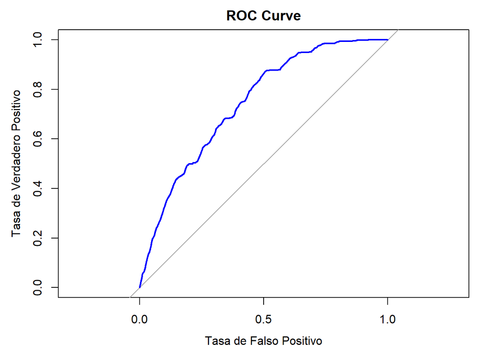

```r
# Creamos el gráfico de la curva ROC:
plot(M1ROC,
     col = "blue",
     lwd = 2,
     main = "ROC Curve",
     xlab = "Tasa de Falso Positivo",
     ylab = "Tasa de Verdadero Positivo",
     legacy.axes = TRUE)
```

En este caso, la curva ROC está situada por encima de la línea diagonal, siendo el rendimiento del modelo mejor que el que tendría un clasificador aleatorio. No obstante, tiene un margen considerable de mejora para ajustar la curva ROC a la esquina superior izquierda. En concreto, vemos que el actual modelo presenta una relación entre las dos tasas tal que, aumentar el umbral para mejorar la tasa de verdaderos positivos, conllevaría un sacrificio significativo de elevar la tasa de falsos positivos.

En cuanto al valor del área bajo la curva ROC, es decir el AUC, presenta un valor del 74.23%. En otras palabras, el AUC indica la probabilidad de que el modelo asigne una probabilidad mayor a un ejemplo positivo que a un ejemplo negativo elegido al azar. Viéndose que en el 74.23% de los casos asignaría con mayor probabilidad un caso positivo. Teniendo el modelo cierto poder de predicción aunque mejorable.

**Apartado c)**: Predecir TRAREM de los datos del 4º trimestre de 2023 y compárelos con los observados. Comentar los resultados.

```r
# Filtramos los nuevos datos para el cuarto trimestre:
dfM1predicciones = filter(df, TRIM == 4)

# Calculamos las predicciones de las probabilidades para el cuarto trimestre:
M1predicciones_prob = predict(M1,
                              newdata = dfM1predicciones,
                              type = "response")

# Tal y como se vio en clase, primero clasificamos las predicciones:
M1predicciones_val = ifelse(M1predicciones_prob > 0.5, "Sí", "No")

# Posteriormente, creamos la tabla de contingencia:
M1contingencia = table(Predicción = M1predicciones_val, Observado = dfM1predicciones$TRAREM)
M1contingencia
```

```
##           Observado
## Predicción    No    Sí
##         No 41717 17675
##         Sí 16737 27542
```

```r
# Finalmente, calculamos la tasa de acierto y de error del modelo:
M1acierto = mean(M1predicciones_val == dfM1predicciones$TRAREM)
M1acierto
```

```
## [1] 0.6680653
```

```r
M1error = mean(M1predicciones_val != dfM1predicciones$TRAREM)
M1error
```

```
## [1] 0.3319347
```

De esta manera vemos que, el modelo entrenado con los datos de los primeros tres trimestres predice el 66.80% de los datos de *TRAREM* del cuarto trimestre del mismo año. Lo que supone un ajuste mejor que el que haría un proceso aleatorio con 50% de probabilidad, aunque con una elevada tasa de error del 33%. Siendo deseable buscar mejores regresiones logísticas con mayor porcentaje de éxito teniendo en cuenta los pocos períodos que se han tomado en los datos de entrenamiento. Probablemente sería ideal tener en cuenta los datos trimestrales de años anteriores para poder predecir la estacionalidad que pudiera haber en los datos de *TRAREM*, dada la alta presencia de empleo estacionario en España, así como, tener en cuenta el tipo de empleo o sector al que aspira el encuestado.

**Apartado d)**: Si consideramos los datos de toda la población, la proporción que ha realizado un trabajo remunerado la semana anterior es del 45,94% en el 1º, 2º y 3º trimestre de 2023. ¿Cómo puede afectar esa información a la regresión logística estimada?

```r
# Vamos a comparar la proporción que ha realizado un trabajo remunerado la semana anterior en los datos de entrenamiento:
mean(dfM1$TRAREM == "Sí")
```

```
## [1] 0.4259356
```

## Ejercicio 2

En el ejercicio 2 se nos pide realizar un análisis lineal discriminante para clasificar a los entrevistados en relación con la actividad económica (AOI) usando los mismos predictores que en el ejercicio anterior y con los datos del 1º, 2º y 3º trimestre de 2023.

```r
# Filtramos los datos para los tres primeros trimestres de 2023:
dfM2 = filter(df2, TRIM != 4)

# Creamos el modelo LDA solicitada:
M2 = MASS::lda(AOI ~ SEXO1 + EDADNum + ECIV1 + NAC1 + NFORMA + EDADEST,
               data = dfM2)
```

**Apartado a)**: Comentar los resultados del LDA.

```r
# Primeramente observamos las estimaciones del modelo:
M2
```

```
## Call:
## lda(AOI ~ SEXO1 + EDADNum + ECIV1 + NAC1 + NFORMA + EDADEST,
##     data = dfM2)
##
## Prior probabilities of groups:
##             Ocupados subempleados por insuficiencia de horas
##                                                  0.036108107
##                                            Resto de ocupados
##                                                  0.450830821
##                             Parados que buscan primer empleo
##                                                  0.006546802
##                              Parados que han trabajado antes
##                                                  0.058016502
##                                     Inactivos 1(desanimados)
##                                                  0.003559998
## Inactivos 2(junto con los desanimados forman los activos pot
##                                                  0.004808631
##                              Inactivos 3(resto de inactivos)
##                                                  0.440129139
##
## Group means:
##                                                              SEXO1Mujer
## Ocupados subempleados por insuficiencia de horas              0.6324867
## Resto de ocupados                                             0.4650017
## Parados que buscan primer empleo                              0.5063890
## Parados que han trabajado antes                               0.5669960
## Inactivos 1(desanimados)                                      0.6562228
## Inactivos 2(junto con los desanimados forman los activos pot  0.5992268
## Inactivos 3(resto de inactivos)                               0.5685413
##                                                               EDADNum
## Ocupados subempleados por insuficiencia de horas             41.52840
## Resto de ocupados                                            45.57063
## Parados que buscan primer empleo                             24.98367
## Parados que han trabajado antes                              42.99223
## Inactivos 1(desanimados)                                     52.00783
## Inactivos 2(junto con los desanimados forman los activos pot 44.17010
## Inactivos 3(resto de inactivos)                              55.58218
##                                                              ECIV1Casado
## Ocupados subempleados por insuficiencia de horas               0.4002917
## Resto de ocupados                                              0.5561588
```

[output cut: 160 more lines]

```
## ECIV1Casado                                                         0.06225940
## ECIV1Viudo                                                          0.79555635
## ECIV1Separado o divorciado                                          1.02665280
## NAC1Española y doble nacionalidad                                   1.86578546
## NAC1Extranjera                                                     -3.27428616
## NFORMAPrimera etapa de educación secundaria (códigos 21-24 en CNED  0.05147956
## NFORMAEducación primaria (código 10 en CNED-2014), (código 12 en C -0.42218910
## NFORMASegunda etapa de educación secundaria. Orientación general ( -0.21090460
## NFORMASegunda etapa de educación secundaria. Orientación profesion  0.39051209
## NFORMAEducación superior (códigos 51, 52, 61-63, 71-75, 81 en CNED -0.66129287
## EDADEST                                                             0.02971227
##
## Proportion of trace:
##    LD1    LD2    LD3    LD4    LD5    LD6
## 0.8775 0.0998 0.0170 0.0041 0.0010 0.0007
```

En los resultados del modelo LDA previos, se exponen las probabilidades observadas para cada clase de la variable de respuesta, dentro de los datos de entrenamiento. Además de verse estas mismas probabilidades condicionadas para cada valor dado de las variables explicativas cualitativas en los datos observados. Así, podemos ver que las clases predominantes de la variable *AOI* en los datos son: Resto de ocupados (45.08%) y “Inactivos 3 (resto de inactivos)” (44.01%).

Otro dato a destacar es la diferencia de edad promedio para cada clase en los datos observados, llamando la atención que los grupos de “Inactivos 3 (resto de inactivos)” y “Inactivos 1 (desanimados)” tienen mayores edades promedio (55.58 y 52 años respectivamente), mientras que los “Parados que buscan primer empleo” tienen una edad promedio significativamente menor (24.98 años). Por lo tanto, la *EDADNum* presenta indicios de ser una variable explicativa de gran importancia para clasificar las diferentes clases.

Finalmente, en cuanto a los coeficientes de las funciones discriminantes, estas describen las combinaciones lineales de predictores que maximizan la separación entre los grupos. Siendo así, en este caso, un 87.75% de la variabilidad capturada por LD1, lo que indica que es la función discriminante más importante para separar los grupos. Por lo que, resulta de interés observar las variables con mayor peso en LD1 como:

- *NFORMAEducación superior*: con el mayor coeficiente negativo de -2.0357, indicando que mayores niveles educativos, especialmente la educación superior respecto al valor base, tienden a estar asociados con clases específicas, tal y como hemos visto en las probabilidades previas al modelo con el grupo de “Resto de ocupados” (0.4695169).

**Apartado b)**: Llevar a cabo el contraste de homogeneidad de Bartlett y el contraste M-Box sobre las dos variables numéricas según la variable de respuesta. Si la conclusión así lo indica, realizar el análisis discriminante cuadrático con validación cruzada.

```r
# A continuación aplicamos el contraste de Bartlett, para verificar la homogeneidad de varianzas entre grupos:
# Primero, extraemos los valores de interés creando dos matrices:
t1 = cbind(dfM2$EDADNum, dfM2$AOI)
t2 = cbind(dfM2$EDADEST, dfM2$AOI)

# Combinamos las matrices en filas:
t3 = rbind(t1, t2)

# Aplicamos el Barlett test:
bartlett.test(t3[,1], t3[,2])
```

```
##
##  Bartlett test of homogeneity of variances
##
## data:  t3[, 1] and t3[, 2]
## Bartlett's K-squared = 60604, df = 6, p-value < 2.2e-16
```

```r
# Aplicamos también el contraste M-Box, preparando la matriz como hemos visto en clase:
M2_MBox = matrix(c(dfM2$EDADNum, dfM2$EDADEST),
                 nrow = length(dfM2$EDADNum))

# Test M-Box:
boxM(M2_MBox, dfM2$AOI)
```

```
##
##  Box's M-test for Homogeneity of Covariance Matrices
##
## data:  M2_MBox
## Chi-Sq (approx.) = 33546, df = 18, p-value < 2.2e-16
```

El contraste de Barlett es utilizado para verificar la homogeneidad de las varianzas entre las distintas clases de la variable de respuesta. Siendo la hipótesis nula que las varianzas son iguales en todos los grupos. En este caso, vemos que el p-valor es menor a 0.05, rechazándose así la hipótesis nula. De modo que, las varianzas parecen ser heterogéneas entre clases, pudiéndose ver el rendimiento del LDA afectado y siendo las predicciones derivadas del modelo no fiables.

El contraste de M-Box evalúa la igualdad de las matrices de covarianza entre los grupos definidos por la variable de respuesta en un análisis discriminante. Siendo la hipótesis nula que las matrices de covarianza son iguales entre los grupos de la variable de respuesta. En este caso, vemos de nuevo que el p-valor es menor a 0.05, rechazándose así la hipótesis nula. Por lo que, ambos contrastes indican la necesidad de aplicar otros modelos como el análisis discriminante cuadrático (QDA).

```r
# Creamos el modelo QDA:
M2_QDA = MASS::qda(AOI ~ SEXO1 + EDADNum + ECIV1 + NAC1 + NFORMA + EDADEST,
                   data = dfM2)
```

**Apartado c)**: Predice AOI de los datos del 4º trimestre de 2023 con el modelo más adecuado y compárelos con los observados. Comentar los resultados.

```r
# Filtramos los nuevos datos para el cuarto trimestre:
dfM2predicciones = filter(df2, TRIM == 4)

# Calculamos las predicciones de las probabilidades para el cuarto trimestre:
M2predicciones = predict(M2_QDA, dfM2predicciones)$class

# Posteriormente, creamos la tabla de contingencia:
M2contingencia = table(Predicción = M2predicciones, Observado = dfM2predicciones$AOI)
M2contingencia
```

```
##                                                               Observado
## Predicción                                                    Ocupados subempleados por insuficiencia de horas
##   Ocupados subempleados por insuficiencia de horas                                                          386
##   Resto de ocupados                                                                                        2615
##   Parados que buscan primer empleo                                                                          406
##   Parados que han trabajado antes                                                                           107
##   Inactivos 1(desanimados)                                                                                    8
##   Inactivos 2(junto con los desanimados forman los activos pot                                                0
##   Inactivos 3(resto de inactivos)                                                                           151
##                                                               Observado
## Predicción                                                    Resto de ocupados
##   Ocupados subempleados por insuficiencia de horas                          2220
##   Resto de ocupados                                                        40105
##   Parados que buscan primer empleo                                          2438
##   Parados que han trabajado antes                                            473
##   Inactivos 1(desanimados)                                                    20
##   Inactivos 2(junto con los desanimados forman los activos pot                 0
##   Inactivos 3(resto de inactivos)                                           1731
##                                                               Observado
## Predicción                                                    Parados que buscan primer empleo
##   Ocupados subempleados por insuficiencia de horas                                           41
##   Resto de ocupados                                                                         218
##   Parados que buscan primer empleo                                                          311
##   Parados que han trabajado antes                                                             4
##   Inactivos 1(desanimados)                                                                    0
##   Inactivos 2(junto con los desanimados forman los activos pot                                0
##   Inactivos 3(resto de inactivos)                                                            50
##                                                               Observado
## Predicción                                                    Parados que han trabajado antes
##   Ocupados subempleados por insuficiencia de horas                                         460
##   Resto de ocupados                                                                       3953
##   Parados que buscan primer empleo                                                         713
##   Parados que han trabajado antes                                                          129
##   Inactivos 1(desanimados)                                                                  13
##   Inactivos 2(junto con los desanimados forman los activos pot                               0
##   Inactivos 3(resto de inactivos)                                                          464
##                                                               Observado
## Predicción                                                    Inactivos 1(desanimados)
##   Ocupados subempleados por insuficiencia de horas                                   16
##   Resto de ocupados                                                                 260
```

[output cut: 8 more lines]

```
##   Resto de ocupados                                                                                                     328
##   Parados que buscan primer empleo                                                                                       91
##   Parados que han trabajado antes                                                                                        11
##   Inactivos 1(desanimados)                                                                                                1
##   Inactivos 2(junto con los desanimados forman los activos pot                                                            0
##   Inactivos 3(resto de inactivos)                                                                                        66
##                                                               Observado
## Predicción                                                    Inactivos 3(resto de inactivos)
##   Ocupados subempleados por insuficiencia de horas                                         900
##   Resto de ocupados                                                                      18705
##   Parados que buscan primer empleo                                                        7154
##   Parados que han trabajado antes                                                          448
##   Inactivos 1(desanimados)                                                                  74
##   Inactivos 2(junto con los desanimados forman los activos pot                               0
##   Inactivos 3(resto de inactivos)                                                        18472
```

```r
# Finalmente, calculamos la tasa de acierto y de error del modelo:
M2acierto = mean(M2predicciones == dfM2predicciones$AOI)
M2acierto
```

```
## [1] 0.5730146
```

```r
M2error = mean(M2predicciones != dfM2predicciones$AOI)
M2error
```

```
## [1] 0.4269854
```

En general, vemos que el modelo posee una tasa de acierto o de clasificación a la verdadera clase del 57.30% y una tasa de error del 42.70% para los datos del cuarto trimestre. Dichas tasas indican que el modelo tiene cierta capacidad predictiva, proporcionando un mayor acierto que el que haría un proceso aleatorio. A continuación normalizamos la tabla de contingencia por columnas y renombramos las clases para visualizarlo mejor.

```r
M2contingencia_normalizada = prop.table(M2contingencia, margin = 2) * 100
colnames(M2contingencia_normalizada) = c("Sub",
                                         "Resto oc.",
                                         "Par. 1º emp.",
                                         "Parados",
                                         "Inact. 1",
                                         "Inact. 2",
                                         "Inact. 3")

rownames(M2contingencia_normalizada) = c("Sub",
                                         "Resto oc.",
                                         "Par. 1º emp.",
                                         "Parados",
                                         "Inact. 1",
                                         "Inact. 2",
                                         "Inact. 3")

M2contingencia_normalizada
```

```
##               Observado
## Predicción            Sub   Resto oc. Par. 1º emp.     Parados    Inact. 1
##   Sub          10.50912061  4.72471109   6.57051282  8.02512212  4.28954424
##   Resto oc.    71.19520828 85.35339562  34.93589744 68.96371249 69.70509383
##   Par. 1º emp. 11.05363463  5.18866921  49.83974359 12.43893929  6.70241287
##   Parados       2.91315001  1.00666142   0.64102564  2.25052338  1.60857909
##   Inact. 1      0.21780561  0.04256496   0.00000000  0.22679693  0.53619303
##   Inact. 2      0.00000000  0.00000000   0.00000000  0.00000000  0.00000000
##   Inact. 3      4.11108086  3.68399770   8.01282051  8.09490579 17.15817694
##               Observado
## Predicción       Inact. 2    Inact. 3
##   Sub           6.04914934  1.96708413
##   Resto oc.    62.00378072 40.88256508
##   Par. 1º emp. 17.20226843 15.63613315
##   Parados       2.07939509  0.97917076
##   Inact. 1      0.18903592  0.16173803
##   Inact. 2      0.00000000  0.00000000
##   Inact. 3     12.47637051 40.37330885
```

De esta manera podemos ver más fácilmente que, las clases donde se han presentado mayores tasas de error han sido en:

- *Sub* (Ocupados subempleados por insuficiencia de horas): donde la mayor parte se han clasificado erróneamente a Resto de ocupados, un 71.20% del grupo.
- *Parados* (Parados que han trabajado antes): donde la mayor parte se han clasificado erróneamente a Resto de ocupados, un 68.96% del grupo.
- *Inact. 1*, *Inact. 2* y *Inact. 3* han sido clasificados con una elevada proporción en Resto de ocupados, un 69.71%, 62% y 40.88% respectivamente. No obstante, *Inact. 3* ha obtenido una tasa de clasificación a la clase verdadera del 40.37% muy diferente de la obtenida en *Inact. 1* y *Inact. 2*, donde es prácticamente del 0-0.5% para ambas.

Es decir, que el modelo sobrestima la probabilidad de pertenecer a la clase de Resto de ocupados (clase con mayor presencia observada) especialmente para todas aquellas clases que de por sí, presentaron una presencia muy baja en las probabilidades previas al modelo. Siendo el caso de *Inact. 1*, *Inact. 2*, *Parados* y *Sub*. Cabe mencionar que, pese a que desde un inicio *Par. 1º emp* tenía una baja presencia en los datos como las anteriores variables, la elevada diferencia en cuanto a su promedio de edad más bajo (24.98 años) determina que no tenga la elevada tasa de error que hemos comentado para el resto de clases.

## Ejercicio 3

En el ejercicio 3 se nos pide estudiar mediante árboles de regresión la antigüedad en la empresa (variable DCOM) con los datos del 1º, 2º y 3º trimestre de 2023, usando como predictores aquellos que se consideren dentro de los datos demográficos, de formación o trabajo dentro de la semana de referencia (columnas de la 1 a la 43 del data frame). Además de predecir DCOM de los datos del 4º trimestre de 2023 mediante bosques aleatorios y boosting. Comentando los resultados.

Cabe puntualizar primeramente que, en el enunciado se especifica escoger las 43 primeras columnas del dataframe de Microdatos, no obstante, podría no tener sentido incluir todas las variables. Además, muchas de ellas están definidas bajo determinadas circunstancias.

Por otra parte, los datos de *DCOM* son registrados únicamente para personas ocupadas. De modo que, se deduce que el objetivo del modelo es conocer la antigüedad para únicamente personas ocupadas, eliminando el resto de datos.

Así, a continuación se puede ver que aparecen valores NA en las siguientes variables, dadas sus diferentes naturalezas:

- *NCONY, NPADRE, NMADRE*: todas ellas comparten la peculiaridad de únicamente presentar un valor en formato texto, cuando no residen en la misma vivienda o no tienen a la persona correspondiente (cónyugue, padre o madre). De este modo, suponemos que los valores NA son aquellos casos en los que sí se aplica la condición, por lo que sustituimos los valores NA por “Reside en la vivienda”.
- *PRONA1*: indica la provincia de nacimiento para personas nacidas en España. De este modo, suponemos que los valores NA son aquellos casos en los que se ha nacido fuera de España, por lo que sustituimos los valores NA por “Extranjero”.
- *REGNA1*: Indica la región del país extranjero de nacimiento para personas nacidas en el extranjero. De este modo, suponemos que los valores NA son aquellos casos en los que se ha nacido en España, por lo que sustituimos los valores NA por “España”.
- *EXTREGNA*: Indica la región del país de la nacionalidad extranjera, para todas las personas con nacionalidad extranjera o doble nacionalidad. Sustituimos los valores NA por “España”.
- *ANORE1*: Indica años de residencia en España Extranjeros o nacidos en España que han residido fuera del país por un período superior o igual a 1 año (0-99) y 0 para menos de un año en España. En este caso, suponemos que aquellos valores NA representan casos en los que se ha nacido en España y no se ha residido nunca fuera de España, por lo que sustituimos NA por la edad.
- *NCURSR*: Indica el nivel de los estudios reglados que cursa para todas las personas de 16 y más años que han cursado estudios reglados durante las 4 últimas semanas CNED 2014 (11-81) CNED 2000 (11-61). Por lo que, sustituimos los valores NA por “No estudia”.
- *OBJFORM*: Indica el objetivo de la formación no reglada para todas las personas. Por lo que sería el mismo caso que el anterior, “No estudia”.
- *AYUDFA*: Indica ayuda familiar, es decir, la realización de trabajo no remunerado empresa familiar para todas las personas que no trabajaron en la semana de referencia a cambio de remuneración. Por lo que, sustituimos los valores NA por “No aplica”.
- *AUSENT*: Indica, a pesar de no haber trabajado ¿tenía un empleo o negocio? para todas las personas que no trabajaron en la semana de referencia a cambio de remuneración. Sustituimos NA por “No aplica”.
- *RZNOTB*: Indica razones por las que no trabajó, teniendo empleo para todas las personas que no trabajaron la semana de referencia, ni ayudan en el negocio familiar, y tenían empleo.
- *VINCUL*: Indica la vinculación con el empleo de personas con empleo ausentes en la semana de referencia para personas que tenían un empleo del cual estaban ausentes la semana de referencia.
- *NUEVEM*: Indica si ha encontrado empleo para personas de 16 a 74 años sin empleo y que no han buscado uno en las cuatro últimas semanas.
- *SP*: Indica el tipo de administración en la que trabaja para todos los asalariados del sector público.
- *DUCON1, DUCON2 y DUCON3*: Indican si tiene contrato indefinido o temporal para todos los asalariados; relación laboral de carácter permanente o discontinuo para asalariados con contrato o relación laboral indefinidos; y tipo de contrato o relación laboral de carácter temporal para asalariados con contrato temporal.

Obviar la siguiente parte, lo intenté pero es un proceso excesivamente tedioso.

```r
# Filtramos los datos para los tres primeros trimestres de 2023:
dfM3 = filter(df3, TRIM != 4) %>%
       filter(!is.na(DCOM)) %>%             # Eliminamos los valores NA de DCOM.
       mutate(NCONY = ifelse(is.na(NCONY), "Reside en la vivienda", as.character(NCONY)),
              NPADRE = ifelse(is.na(NPADRE), "Reside en la vivienda", as.character(NPADRE)),
              NMADRE = ifelse(is.na(NMADRE), "Reside en la vivienda", as.character(NMADRE)),
              PRONA1 = ifelse(is.na(PRONA1), "Extranjero", as.character(PRONA1)),
              REGNA1 = ifelse(is.na(REGNA1), "España", as.character(REGNA1)),
              EXREGNA1 = ifelse(is.na(EXREGNA1), "España", as.character(EXREGNA1)),
              ANORE1 = ifelse(is.na(ANORE1), EDADNum, ANORE1),
              NCURSR = ifelse(is.na(NCURSR), "No estudia", as.character(NCURSR)),
              OBJFORM = ifelse(is.na(OBJFORM), "No estudia", as.character(OBJFORM)),
              AYUDFA = ifelse(is.na(AYUDFA), "No aplica", as.character(AYUDFA)),
              AUSENT = ifelse(is.na(AUSENT), "No aplica", as.character(AUSENT)),
              RZNOTB = ifelse(is.na(RZNOTB), "No aplica", as.character(RZNOTB)),
              VINCUL = ifelse(is.na(VINCUL), "No aplica", as.character(VINCUL)),
              NUEVEM = ifelse(is.na(NUEVEM), "No aplica", as.character(NUEVEM)),
              SP = ifelse(is.na(SP), "No aplica", as.character(SP)),
              DUCON1 = ifelse(is.na(DUCON1), "No aplica", as.character(DUCON1)),
              DUCON2 = ifelse(is.na(DUCON2), "No aplica", as.character(DUCON2)),
              DUCON3 = ifelse(is.na(DUCON3), "No aplica", as.character(DUCON3)),
              CICLO = droplevels(CICLO))

# Transformamos a factores las variables que hemos modificado:
dfM3 = dfM3 %>%
  mutate(NCONY = as.factor(NCONY),
         NPADRE = as.factor(NPADRE),
         NMADRE = as.factor(NMADRE),
         PRONA1 = as.factor(PRONA1),
         REGNA1 = as.factor(REGNA1),
         EXREGNA1 = as.factor(EXREGNA1),
         NCURSR = as.factor(NCURSR),
         OBJFORM = as.factor(OBJFORM),
         AYUDFA = as.factor(AYUDFA),
         AUSENT = as.factor(AUSENT),
         RZNOTB = as.factor(RZNOTB),
         VINCUL = as.factor(VINCUL),
         NUEVEM = as.factor(NUEVEM),
         SP = as.factor(SP),
         DUCON1 = as.factor(DUCON1),
         DUCON2 = as.factor(DUCON2),
         DUCON3 = as.factor(DUCON3))

# Eliminamos aquellas variables que no aportan información o tienen más de 32 categorías:
dfM3 = dfM3 %>%
       dplyr::select(-CICLO, -PROV, -NVIVI, -NPERS, -EDAD1, -RELPP1, -PRONA1, -RELLB1, -NUEVEM)

# Redefinimos las etiquetas para nombres más cortos:
dfM3$DUCON3 = factor(dfM3$DUCON3,
                      levels = c("Cubre la ausencia total o parcial de otro trabajador",
                                 "Cubre un período de prueba",
                                 "De formación o aprendizaje",
                                 "Estacional o de temporada",
                                 "Eventual por circunstancias de la producción",
                                 "No aplica",
                                 "No sabe",
                                 "Otro tipo",
                                 "Para obra o servicio determinado",
                                 "Verbal no incluido en las opciones anteriores"),
                      labels = c("Ausencia", "Prueba", "Formación", "Temporal",
                                 "Producción", "No aplica", "No sabe",
                                 "Otro", "Obra/servicio", "Verbal"))



# Comprobamos los valores NA que aparecen:
colSums(is.na(dfM3))

# Creamos el modelo de árboles de regresión solicitada:
M3 = tree(DCOM ~ .,
          data = dfM3)

# Vemos los resultados:
summary(M3)

# Visualizamos el árbol:
plot(M3)
text(M3, pretty = 0)
```

```r
# No me complico y quito todas las columnas con NA:
dfM4 = filter(df3, TRIM != 4) %>%
       filter(!is.na(DCOM)) %>%
       dplyr::select(-CICLO, -PROV, -NVIVI, -NPERS,
                     -EDAD1, -RELPP1, -PRONA1, -RELLB1,
                     -NUEVEM, -AYUDFA, -AUSENT, -RZNOTB,
                     -VINCUL, -EXREGNA1, -ANORE1, -NCONY,
                     -NPADRE, -NMADRE, -NCURSR, -REGNA1,
                     -DUCON3, -OBJFORM, -SP, -DUCON1, -DUCON2)

dfM4$SITU = factor(dfM4$SITU,
                    levels = c("Empresario con asalariados",
                               "Trabajador independiente o empresario sin asalariados",
                               "Miembro de una cooperativa",
                               "Ayuda en la empresa o negocio familiar",
                               "Asalariado sector público",
                               "Asalariado sector privado",
                               "Otra situación"),
                    labels = c("Empresario",
                               "Independiente",
                               "Cooperativa",
                               "Ayuda familiar",
                               "Sector público",
                               "Sector privado",
                               "Otro"))

dfM4$NAC1 = factor(dfM4$NAC1,
                    levels = c("Española",
                               "Española y doble nacionalidad",
                               "Extranjera"),
                    labels = c("Española",
                               "Doble nacionalidad",
                               "Extranjera"))


# Comprobamos que no hay NA:
colSums(is.na(dfM4))
```

```
##     DCOM     ANYO     TRIM     CCAA    NIVEL  EDADNum    SEXO1 RELLMILI
##        0        0        0        0        0        0        0        0
##    ECIV1     NAC1   NFORMA  EDADEST    CURSR   CURSNR   RELLB2   TRAREM
##        0        0        0        0        0        0        0        0
##    OCUP1     ACT1     SITU
##        0        0        0
```

```r
# Creamos el modelo de árboles de regresión solicitada:
M4 = tree(DCOM ~ .,
          data = dfM4)

# Mostramos los resultados:
summary(M4)
```

```
##
## Regression tree:
## tree(formula = DCOM ~ ., data = dfM4)
## Variables actually used in tree construction:
## [1] "EDADNum" "SITU"    "NAC1"
## Number of terminal nodes:  6
## Residual mean deviance:  11810 = 1.855e+09 / 157200
## Distribution of residuals:
##    Min. 1st Qu.  Median    Mean 3rd Qu.    Max.
## -333.30  -67.12  -14.57    0.00   75.27  519.20
```

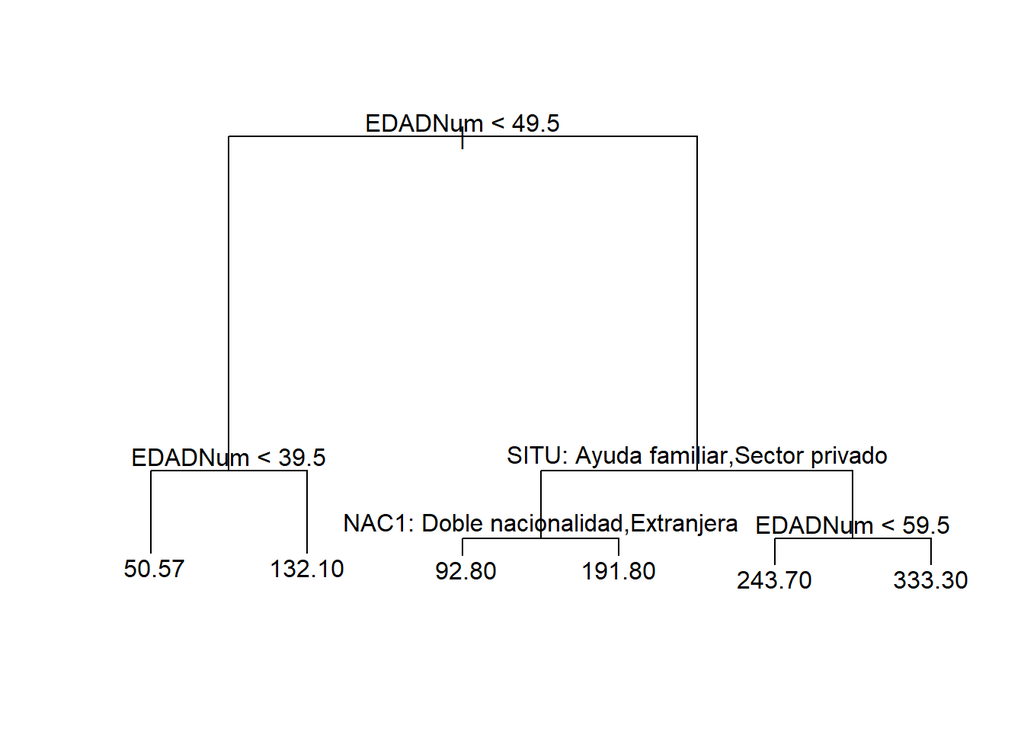

```r
# Graficamos el árbol de decisión:
plot(M4)
text(M4, pretty = 0)
```

La primera división se realiza en función de la variable EDADNum. Las personas con EDADNum < 49.5 van hacia el nodo izquierdo; de lo contrario, van hacia el nodo derecho. En cuanto a las subdivisiones, en el lado izquierdo:

- Si EDADNum < 39.5, se predice un valor promedio de antigüedad de 50.57.
- Si EDADNum >= 39.5, se predice un valor promedio de antigüedad de 132.10.

En el lado derecho:

- Si SITU es “Ayuda familiar” o “Sector privado”, se realizan dos caminos:
- Si la nacionalidad (NAC1) es “Doble nacionalidad” o “Extranjera”, se predice un promedio de 92.80. De lo contrario, se predice un promedio de 191.80.
- Si EDADNum < 59.5, se predice un promedio de 243.70.
- Si EDADNum >= 59.5, se predice un promedio de 333.30.

Hay que tener en cuenta que hablamos de meses de antigüedad en la empresa.

```r
# Creamos el dataset:
dfM5 = filter(df3, TRIM != 4) %>%
       dplyr::select(DCOM, EDADNum, SEXO1, ECIV1, NAC1,
                     NFORMA, EDADEST, CURSR, TRAREM) %>%
       filter(!is.na(DCOM))

dfM5predicciones = filter(df3, TRIM == 4) %>%
                   dplyr::select(DCOM, EDADNum, SEXO1, ECIV1, NAC1,
                                 NFORMA, EDADEST, CURSR, TRAREM) %>%
                   filter(!is.na(DCOM))

# Creamos el modelo de árboles de regresión solicitada:
M5_tree = tree(DCOM ~ .,
               data = dfM5)

# Creamos un randomForest con las variables que considero relevantes por intuición:
set.seed(11631)
train = sample(1:nrow(dfM5),1000)

M5 = randomForest(DCOM ~ EDADNum + SEXO1 + ECIV1 + NAC1 + NFORMA + EDADEST + CURSR + TRAREM,
                  data = dfM5,
                  ntree = 200,
                  subset = train)

# Mostramos los resultados:
summary(M5)
```

```
##                 Length Class  Mode
## call               5   -none- call
## type               1   -none- character
## predicted       1000   -none- numeric
## mse              200   -none- numeric
## rsq              200   -none- numeric
## oob.times       1000   -none- numeric
## importance         8   -none- numeric
## importanceSD       0   -none- NULL
## localImportance    0   -none- NULL
## proximity          0   -none- NULL
## ntree              1   -none- numeric
## mtry               1   -none- numeric
## forest            11   -none- list
## coefs              0   -none- NULL
## y               1000   -none- numeric
## test               0   -none- NULL
## inbag              0   -none- NULL
## terms              3   terms  call
```

```r
# Predicciones
pred_rf = predict(M5, newdata = dfM5predicciones)

# Métricas de evaluación
mse_rf = mean((pred_rf - dfM5predicciones$DCOM)^2)
cat("MSE Random Forest:", mse_rf, "\n")
```

```
## MSE Random Forest: 11949
```

```r
# Ajuste del modelo Boosting:
M3_gbm = gbm(DCOM ~ .,
             data = dfM5predicciones,
             distribution = "gaussian",
             n.trees = 200,
             interaction.depth = 3,
             shrinkage = 0.1,
             cv.folds = 5)

# Número óptimo de árboles
best_iter = gbm.perf(M3_gbm, method = "cv")
```

[figure not shown]

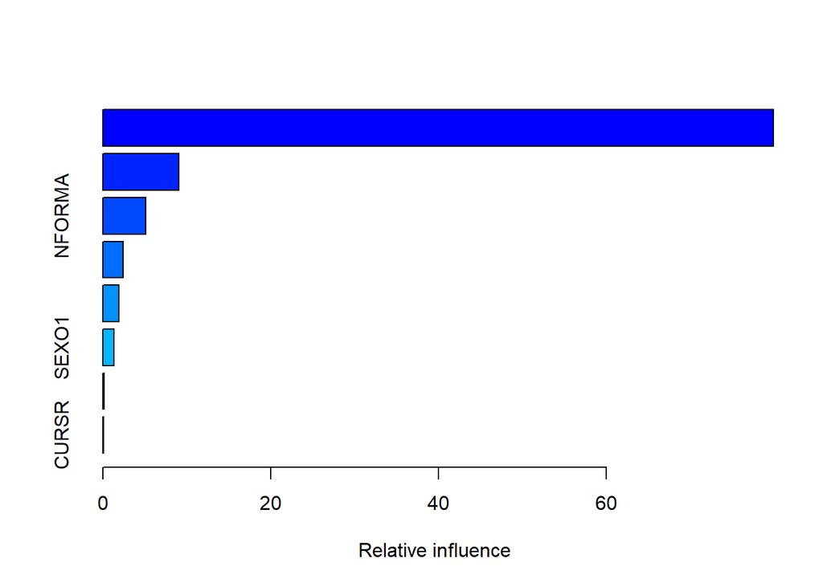

```
##             var    rel.inf
## EDADNum EDADNum 79.8835958
## NAC1       NAC1  9.0550481
## NFORMA   NFORMA  5.1494820
## EDADEST EDADEST  2.3976862
## ECIV1     ECIV1  1.9342666
## SEXO1     SEXO1  1.3286006
## TRAREM   TRAREM  0.1486075
## CURSR     CURSR  0.1027132
```

```r
# Importancia de variables
summary(M3_gbm)
```

```r
# Predicciones
pred_gbm = predict(M3_gbm, newdata = dfM5predicciones, n.trees = best_iter)

# Métricas de evaluación
mse_gbm = mean((pred_gbm - dfM5predicciones$DCOM)^2)

# Comparación de métodos:
cat("MSE Árbol:", mean((predict(M5_tree, newdata = dfM5predicciones) - dfM5predicciones$DCOM)^2), "\n")
```

```
## MSE Árbol: 12096.5
```

```r
cat("MSE Random Forest:", mse_rf, "\n")
```

```
## MSE Random Forest: 11949
```

```r
cat("MSE Boosting:", mse_gbm, "\n")
```

```
## MSE Boosting: 10787.61
```

## Ejercicio 4

En este ejercicio se nos pide aplicar el método que considere más apropiado a los datos de MicrodatosEPA.RData con la finalidad de predecir la actividad principal (la variable ACT1) del 4º trimestre de 2024 (los datos de este periodo serán publicados por el INE el 28 de enero de 2025). El modelo elegido debe tener el nombre “Pregunta_4” y el que presente el porcentaje de acierto más elevado entre todos los entregados tendrá un punto extra en la nota de la práctica 3.

La variable *ACT1* comprende los siguientes niveles asignables:

- Agricultura, ganadería, silvicultura y pesca (códigos CNAE-09: 01, 02 y 03), (códigos CNAE-93: 01, 02 y 05)
- Industria de la alimentación, textil, cuero, madera y papel (códigos CNAE-09: del 10 al 18), (códigos CNAE-93 del 15 al 22)
- Industrias extractivas, refino de petróleo, industria química, farmaceutica, industria del caucho y materias plásticas, suministro energía eléctrica, gas, vapor y aire acondicionado, suministro de agua, gestión de residuos. Metalurgia (códigos CNAE-09: del 05 al 09, del 19 al 25, 35 y del 36 al 39), (códigos CNAE-93: del 10 al 14, del 23 al 28, 40 y 41)
- Construcción de maquinaria, equipo eléctrico y material de transporte. Instalación y reparación industrial (códigos CNAE-09 del 26 al 33), (códigos CNAE-93 del 29 al 37)
- Construcción (códigos CNAE-09: del 41 al 43), (código CNAE-93: 45)
- Comercio al por mayor y al por menor y sus instalaciones y reparaciones. Reparación de automóviles, hostelería (códigos CNAE-09: del 45 al 47, 55 y 56), (códigos CNAE-93: 50, 51, 52 y 55)
- Transporte y almacenamiento. Información y comunicaciones (códigos CNAE-09 del 49 al 53 y del 58 al 63), (códigos CNAE-93 del 60 al 64)
- Intermediación financiera, seguros, actividades inmobiliarias, servicios profesionales, científicos, administrativos y otros (códigos CNAE-09: del 64 al 66, 68, del 69 al 75 y del 77 al 82), (códigos CNAE-93 del 65 al 67 y del 70 al 74)
- Administración Pública, educación y actividades sanitarias (códigos CNAE-09: 84, 85 y del 86 al 88), (códigos CNAE-93: 75, 80 y 85)
- Otros servicios (códigos CNAE-09: del 90 al 93, del 94 al 96, 97y 99), (códigos CNAE-93: del 90 al 93, 95 y 99)

- *TRIM*: es una variable que podría predecir y clasificar ciertos empleos con alta estacionalidad.

```r
# Preparamos el dataset:
dfP4 = dplyr::select(Microdatos, ACT1, TRIM, CCAA, EDADNum, SEXO1, ECIV1, NAC1, NFORMA, EDADEST, CURSR, AOI, TRAREM, ANYO) %>%
        filter(!is.na(ACT1))

# Comprobamos que no hay valores NA:
colSums(is.na(dfP4))
```

```
##    ACT1    TRIM    CCAA EDADNum   SEXO1   ECIV1    NAC1  NFORMA EDADEST   CURSR
##       0       0       0       0       0       0       0       0       0       0
##     AOI  TRAREM    ANYO
##       0       0       0
```

```r
# Dividimos el dataset en entrenamiento (70%) y prueba (30%)
set.seed(11631)
train_indices = sample(1:nrow(dfP4), size = 0.7 * nrow(dfP4))
train_data = dfP4[train_indices, ]
test_data = dfP4[-train_indices, ]

# Reducimos el tamaño del dataset de entrenamiento para acelerar el modelo
set.seed(11631)
train_data = train_data[sample(1:nrow(train_data), size = min(1000, nrow(train_data))), ]

# Modelo 1: SVM con kernel lineal
set.seed(11631)
svm_linear = svm(ACT1 ~ ., data = train_data, kernel = "linear", cost = 1, scale = TRUE)

# Predicciones y matriz de confusión para el kernel lineal
pred_linear <- predict(svm_linear, test_data)
conf_matrix_linear <- table(Predicted = pred_linear, Actual = test_data$ACT1)
cat("Matriz de confusión para kernel lineal:\n")
```

```
## Matriz de confusión para kernel lineal:
```

```r
colnames(conf_matrix_linear) = c("Agr.",
                               "Ind.alim.",
                               "Ind.extr.",
                               "Constr.maq.",
                               "Constr.",
                               "Comercio",
                               "Transp.",
                               "Financ.",
                               "AAPP",
                               "Otros")
rownames(conf_matrix_linear) = c("Agr.",
                               "Ind.alim.",
                               "Ind.extr.",
                               "Constr.maq.",
                               "Constr.",
                               "Comercio",
                               "Transp.",
                               "Financ.",
                               "AAPP",
                               "Otros")
print(conf_matrix_linear)
```

```
##              Actual
## Predicted      Agr. Ind.alim. Ind.extr. Constr.maq. Constr. Comercio Transp.
##   Agr.          199        71        50          37      92      329      96
##   Ind.alim.      33        14        12           8      32       55      36
##   Ind.extr.      17        49       113         102      76      144     101
##   Constr.maq.     2        33        80          90      29       62      67
##   Constr.       453       395       380         230     748      960     473
##   Comercio     2747      2355      2055        1556    3302    11826    3049
##   Transp.       239       288       312         280     521     1272     976
##   Financ.        46       139       290         280     205      868     673
##   AAPP          993      1740      2390        1960    1908     8179    3303
##   Otros          40        33         8           4      17      135      18
##              Actual
## Predicted     Financ.  AAPP Otros
##   Agr.             58    63    78
##   Ind.alim.        18    14    12
##   Ind.extr.        94   105    36
##   Constr.maq.      69   115    17
##   Constr.         252   260   136
##   Comercio       3867  5083  3487
##   Transp.         932   973   346
##   Financ.        1460  2286   381
##   AAPP           6949 18964  2411
##   Otros            23    35    67
```

```r
# Precisión del kernel lineal
accuracy_linear <- sum(diag(conf_matrix_linear)) / sum(conf_matrix_linear)
cat("Precisión del kernel lineal:", accuracy_linear, "\n")
```

```
## Precisión del kernel lineal: 0.3182624
```

```r
# Modelo 2: SVM con kernel radial
set.seed(11631)
svm_radial <- svm(ACT1 ~ ., data = train_data, kernel = "radial", cost = 1, gamma = 0.1, scale = TRUE)

# Predicciones y matriz de confusión para el kernel radial
pred_radial <- predict(svm_radial, test_data)
conf_matrix_radial <- table(Predicted = pred_radial, Actual = test_data$ACT1)
cat("Matriz de confusión para kernel radial:\n")
```

```
## Matriz de confusión para kernel radial:
```

```r
colnames(conf_matrix_radial) = c("Agr.",
                               "Ind.alim.",
                               "Ind.extr.",
                               "Constr.maq.",
                               "Constr.",
                               "Comercio",
                               "Transp.",
                               "Financ.",
                               "AAPP",
                               "Otros")
rownames(conf_matrix_radial) = c("Agr.",
                               "Ind.alim.",
                               "Ind.extr.",
                               "Constr.maq.",
                               "Constr.",
                               "Comercio",
                               "Transp.",
                               "Financ.",
                               "AAPP",
                               "Otros")
print(conf_matrix_radial)
```

```
##              Actual
## Predicted      Agr. Ind.alim. Ind.extr. Constr.maq. Constr. Comercio Transp.
##   Agr.            0         0         0           0       0        0       0
##   Ind.alim.       0         0         0           0       0        0       0
##   Ind.extr.       0         0         0           0       0        0       0
##   Constr.maq.     0         0         0           0       0        0       0
##   Constr.         3         2         2           1       6        8       1
##   Comercio     3658      3135      2892        2137    4718    14643    4254
##   Transp.         6        10        24          26      29       66     103
##   Financ.         5        18        29          36      37       59      98
##   AAPP         1097      1952      2743        2347    2140     9054    4336
##   Otros           0         0         0           0       0        0       0
##              Actual
## Predicted     Financ.  AAPP Otros
##   Agr.              0     0     0
##   Ind.alim.         0     0     0
##   Ind.extr.         0     0     0
##   Constr.maq.       0     0     0
##   Constr.           3     2     0
##   Comercio       4523  5517  3989
##   Transp.         128    63    16
##   Financ.         132   121    30
##   AAPP           8936 22195  2936
##   Otros             0     0     0
```

```r
# Precisión del kernel radial
accuracy_radial <- sum(diag(conf_matrix_radial)) / sum(conf_matrix_radial)
cat("Precisión del kernel radial:", accuracy_radial, "\n")
```

```
## Precisión del kernel radial: 0.3424806
```

```r
# Modelo 3: SVM con kernel polinómico
set.seed(11631)
svm_poly <- svm(ACT1 ~ ., data = train_data, kernel = "polynomial", degree = 3, cost = 1, scale = TRUE)

# Predicciones y matriz de confusión para el kernel polinómico
pred_poly <- predict(svm_poly, test_data)
conf_matrix_poly <- table(Predicted = pred_poly, Actual = test_data$ACT1)
cat("Matriz de confusión para kernel polinómico:\n")
```

```
## Matriz de confusión para kernel polinómico:
```

```r
colnames(conf_matrix_poly) = c("Agr.",
                               "Ind.alim.",
                               "Ind.extr.",
                               "Constr.maq.",
                               "Constr.",
                               "Comercio",
                               "Transp.",
                               "Financ.",
                               "AAPP",
                               "Otros")
rownames(conf_matrix_poly) = c("Agr.",
                               "Ind.alim.",
                               "Ind.extr.",
                               "Constr.maq.",
                               "Constr.",
                               "Comercio",
                               "Transp.",
                               "Financ.",
                               "AAPP",
                               "Otros")
print(conf_matrix_poly)
```

```
##              Actual
## Predicted      Agr. Ind.alim. Ind.extr. Constr.maq. Constr. Comercio Transp.
##   Agr.            0         0         0           0       0        0       0
##   Ind.alim.       0         0         0           0       0        0       0
##   Ind.extr.       0         0         0           0       0        0       0
##   Constr.maq.     0         0         0           0       0        0       0
##   Constr.         0         0         0           0       0        0       0
##   Comercio        0         0         0           0       0        0       0
##   Transp.         0         0         0           0       0        0       0
##   Financ.         0         0         0           0       0        0       0
##   AAPP         4769      5117      5690        4547    6930    23830    8792
##   Otros           0         0         0           0       0        0       0
##              Actual
## Predicted     Financ.  AAPP Otros
##   Agr.              0     0     0
##   Ind.alim.         0     0     0
##   Ind.extr.         0     0     0
##   Constr.maq.       0     0     0
##   Constr.           0     0     0
##   Comercio          0     0     0
##   Transp.           0     0     0
##   Financ.           0     0     0
##   AAPP          13722 27898  6971
##   Otros             0     0     0
```

```r
# Precisión del kernel polinómico
accuracy_poly <- sum(diag(conf_matrix_poly)) / sum(conf_matrix_poly)
cat("Precisión del kernel polinómico:", accuracy_poly, "\n")
```

```
## Precisión del kernel polinómico: 0.2576802
```

```r
# Modelo 4: SVM con kernel sigmoid
set.seed(11631)
svm_sigmoid <- svm(ACT1 ~ ., data = train_data, kernel = "sigmoid", cost = 1, scale = TRUE)

# Predicciones y matriz de confusión para el kernel sigmoid
pred_sigmoid <- predict(svm_sigmoid, test_data)
conf_matrix_sigmoid <- table(Predicted = pred_sigmoid, Actual = test_data$ACT1)
cat("Matriz de confusión para kernel sigmoid:\n")
```

```
## Matriz de confusión para kernel sigmoid:
```

```r
colnames(conf_matrix_sigmoid) = c("Agr.",
                               "Ind.alim.",
                               "Ind.extr.",
                               "Constr.maq.",
                               "Constr.",
                               "Comercio",
                               "Transp.",
                               "Financ.",
                               "AAPP",
                               "Otros")
rownames(conf_matrix_sigmoid) = c("Agr.",
                               "Ind.alim.",
                               "Ind.extr.",
                               "Constr.maq.",
                               "Constr.",
                               "Comercio",
                               "Transp.",
                               "Financ.",
                               "AAPP",
                               "Otros")
print(conf_matrix_sigmoid)
```

```
##              Actual
## Predicted      Agr. Ind.alim. Ind.extr. Constr.maq. Constr. Comercio Transp.
##   Agr.            0         0         0           0       0        0       0
##   Ind.alim.       0         0         0           0       0        0       0
##   Ind.extr.       0         0         0           0       0        0       0
##   Constr.maq.     0         0         0           0       0        0       0
##   Constr.         0         0         0           0       0        0       0
##   Comercio     3909      3294      3110        2255    4936    15827    4431
##   Transp.         0         0         0           0       0        0       0
##   Financ.         0         0         0           0       0        0       0
##   AAPP          860      1823      2580        2292    1994     8003    4361
##   Otros           0         0         0           0       0        0       0
##              Actual
## Predicted     Financ.  AAPP Otros
##   Agr.              0     0     0
##   Ind.alim.         0     0     0
##   Ind.extr.         0     0     0
##   Constr.maq.       0     0     0
##   Constr.           0     0     0
##   Comercio       4868  6464  4319
##   Transp.           0     0     0
##   Financ.           0     0     0
##   AAPP           8854 21434  2652
##   Otros             0     0     0
```

```r
# Precisión del kernel sigmoid
accuracy_sigmoid <- sum(diag(conf_matrix_sigmoid)) / sum(conf_matrix_sigmoid)
cat("Precisión del kernel sigmoid:", accuracy_sigmoid, "\n")
```

```
## Precisión del kernel sigmoid: 0.3441616
```

```r
# Optimización del modelo con kernel radial
set.seed(11631)
tune_radial <- tune(svm, ACT1 ~ ., data = train_data, kernel = "radial",
                    ranges = list(cost = c(0.1, 1, 10), gamma = c(0.01, 0.1, 1)))

# Resumen de la búsqueda
cat("Resultados de la búsqueda de hiperparámetros para kernel radial:\n")
```

```
## Resultados de la búsqueda de hiperparámetros para kernel radial:
```

```r
summary(tune_radial)
```

```
##
## Parameter tuning of 'svm':
##
## - sampling method: 10-fold cross validation
##
## - best parameters:
##  cost gamma
##     1  0.01
##
## - best performance: 0.693
##
## - Detailed performance results:
##   cost gamma error dispersion
## 1  0.1  0.01 0.766 0.03405877
## 2  1.0  0.01 0.693 0.04029061
## 3 10.0  0.01 0.699 0.03510302
## 4  0.1  0.10 0.695 0.03535534
## 5  1.0  0.10 0.696 0.03062316
## 6 10.0  0.10 0.756 0.05541761
## 7  0.1  1.00 0.766 0.03272783
## 8  1.0  1.00 0.733 0.03267687
## 9 10.0  1.00 0.739 0.03314949
```

```r
# Mejor modelo con kernel radial
Pregunta_4 <- tune_radial$best.model

# Predicciones y matriz de confusión para el mejor modelo
best_pred <- predict(Pregunta_4, test_data)
best_conf_matrix <- table(Predicted = best_pred, Actual = test_data$ACT1)
cat("Matriz de confusión del mejor modelo (kernel radial):\n")
```

```
## Matriz de confusión del mejor modelo (kernel radial):
```

```r
colnames(best_conf_matrix) = c("Agr.",
                               "Ind.alim.",
                               "Ind.extr.",
                               "Constr.maq.",
                               "Constr.",
                               "Comercio",
                               "Transp.",
                               "Financ.",
                               "AAPP",
                               "Otros")
rownames(best_conf_matrix) = c("Agr.",
                               "Ind.alim.",
                               "Ind.extr.",
                               "Constr.maq.",
                               "Constr.",
                               "Comercio",
                               "Transp.",
                               "Financ.",
                               "AAPP",
                               "Otros")
print(best_conf_matrix)
```

```
##              Actual
## Predicted      Agr. Ind.alim. Ind.extr. Constr.maq. Constr. Comercio Transp.
##   Agr.            0         0         0           0       0        0       0
##   Ind.alim.       0         0         0           0       0        0       0
##   Ind.extr.       0         0         0           0       0        0       0
##   Constr.maq.     0         0         0           0       0        0       0
##   Constr.         0         0         0           0       0        0       0
##   Comercio     3892      3283      3100        2258    4919    15798    4457
##   Transp.         0         0         0           0       0        0       0
##   Financ.         0         0         0           0       0        0       0
##   AAPP          877      1834      2590        2289    2011     8032    4335
##   Otros           0         0         0           0       0        0       0
##              Actual
## Predicted     Financ.  AAPP Otros
##   Agr.              0     0     0
##   Ind.alim.         0     0     0
##   Ind.extr.         0     0     0
##   Constr.maq.       0     0     0
##   Constr.           0     0     0
##   Comercio       4857  6405  4303
##   Transp.           0     0     0
##   Financ.           0     0     0
##   AAPP           8865 21493  2668
##   Otros             0     0     0
```

```r
# Precisión del mejor modelo
best_accuracy <- sum(diag(best_conf_matrix)) / sum(best_conf_matrix)
cat("Precisión del mejor modelo (kernel radial):", best_accuracy, "\n")
```

```
## Precisión del mejor modelo (kernel radial): 0.3444387
```

```r
# Preparamos el dataset:
dfP4 = dplyr::select(Microdatos, ACT1, TRIM, CCAA, EDADNum, SEXO1, ECIV1, NAC1, NFORMA, EDADEST, CURSR, AOI, TRAREM, ANYO) %>%
        filter(!is.na(ACT1))

# Comprobamos que no hay valores NA:
colSums(is.na(dfP4))
```

```
##    ACT1    TRIM    CCAA EDADNum   SEXO1   ECIV1    NAC1  NFORMA EDADEST   CURSR
##       0       0       0       0       0       0       0       0       0       0
##     AOI  TRAREM    ANYO
##       0       0       0
```

```r
# Dividimos el dataset en entrenamiento (70%) y prueba (30%):
set.seed(11631)
train_indices = sample(1:nrow(dfP4), size = 0.7 * nrow(dfP4))
train_data = dfP4[train_indices, ]
test_data = dfP4[-train_indices, ]

# Reducimos el tamaño del dataset de entrenamiento para acelerar el modelo
set.seed(11631)
train_data = train_data[sample(1:nrow(train_data), size = min(8000, nrow(train_data))), ]

# Entrenamos el modelo final con los mejores hiperparámetros
Pregunta_4 = svm(ACT1 ~ ., data = train_data, kernel = "radial", cost = 1, gamma = 0.1)

# Predicciones
best_pred = predict(Pregunta_4, test_data)

# Matriz de confusión
best_conf_matrix = table(Predicted = best_pred, Observado = test_data$ACT1)
cat("Matriz de confusión del mejor modelo (kernel radial):\n")
```

```
## Matriz de confusión del mejor modelo (kernel radial):
```

```r
colnames(best_conf_matrix) = c("Agr.",
                               "Ind.alim.",
                               "Ind.extr.",
                               "Constr.maq.",
                               "Constr.",
                               "Comercio",
                               "Transp.",
                               "Financ.",
                               "AAPP",
                               "Otros")
rownames(best_conf_matrix) = c("Agr.",
                               "Ind.alim.",
                               "Ind.extr.",
                               "Constr.maq.",
                               "Constr.",
                               "Comercio",
                               "Transp.",
                               "Financ.",
                               "AAPP",
                               "Otros")
print(best_conf_matrix)
```

```
##              Observado
## Predicted      Agr. Ind.alim. Ind.extr. Constr.maq. Constr. Comercio Transp.
##   Agr.            3         0         0           0       0        0       0
##   Ind.alim.       0         0         0           0       0        0       0
##   Ind.extr.       0         0         0           0       0        0       0
##   Constr.maq.     0         0         0           0       0        0       0
##   Constr.        30        14        17          13      45       39      30
##   Comercio     3809      3274      3034        2237    4903    15689    4338
##   Transp.         1         0         2           1       0        2       3
##   Financ.        10        17        14          14      18       95      64
##   AAPP          916      1811      2623        2282    1964     8005    4357
##   Otros           0         1         0           0       0        0       0
##              Observado
## Predicted     Financ.  AAPP Otros
##   Agr.              0     0     0
##   Ind.alim.         0     0     0
##   Ind.extr.         0     0     0
##   Constr.maq.       0     0     0
##   Constr.          14    14    11
##   Comercio       4743  6019  4412
##   Transp.           4     0     1
##   Financ.         109    86    33
##   AAPP           8850 21776  2499
##   Otros             2     3    15
```

```r
# Precisión
best_accuracy = sum(diag(best_conf_matrix)) / sum(best_conf_matrix)
cat("Precisión del mejor modelo:", best_accuracy, "\n")
```

```
## Precisión del mejor modelo: 0.3476622
```

Al observar la matriz de confusión, podemos determinar las áreas donde el modelo clasifica correctamente y las clases donde se presentan más errores.